# Machine_learning - SVM

```python
import os
import numpy as np
import pandas as pd
import matplotlib.pyplot as plt

from sklearn.svm import *
from sklearn.metrics import *
from sklearn.model_selection import *
from sklearn.pipeline import Pipeline
from sklearn.preprocessing import StandardScaler
from sklearn.decomposition import PCA

import warnings
warnings.filterwarnings("ignore")

# Set display options
pd.set_option('display.max_columns', None)  # To display all columns
pd.set_option('display.max_rows', None)     # To display all rows
pd.set_option('display.width', 1000)        # Set the display width to a larger value

RANDOM_SEED = 123
```

```python
from google.colab import drive
drive.mount('/content/drive')
```

```python
# access the data
%cd '/content/drive/MyDrive/Colab Notebooks'
```

```
/content/drive/MyDrive/Colab Notebooks
```

```python
# os.listdir()
```

## *Basic set up to machine learning models*

```python
K_FOLD = 6
kfold = StratifiedKFold(n_splits = K_FOLD, random_state=RANDOM_SEED, shuffle=True) # StratifiedKFold is an extension of KFold where it maintains the distribution of the target variable within each fold.
scoring = {'cohen_kappa_score': make_scorer(cohen_kappa_score),
           'balanced_accuracy_score': make_scorer(balanced_accuracy_score),
           'accuracy': make_scorer(accuracy_score)}
```

## *Call the DataSet*

```python
# ------------------------------------------------------

# Descriptors
train_50_2_4 = np.load('feat_train_50_2_4.npy')
test_50_2_4 = np.load('feat_test_50_2_4.npy')

train_150_2_4 = np.load('feat_train_150_2_4.npy')
test_150_2_4 = np.load('feat_test_150_2_4.npy')

train_50_4_8 = np.load('feat_train_50_4_8.npy')
test_50_4_8 = np.load('feat_test_50_4_8.npy')

train_150_4_8 = np.load('feat_train_150_4_8.npy')
test_150_4_8 = np.load('feat_test_150_4_8.npy')

train_50_6_12 = np.load('feat_train_50_6_12.npy')
test_50_6_12 = np.load('feat_test_50_6_12.npy')

train_150_6_12 = np.load('feat_train_150_6_12.npy')
test_150_6_12 = np.load('feat_test_150_6_12.npy')

# ------------------------------------------------------

# Descriptors PCA
pca_train_50_2_4 = np.load('pca_feat_train_50_2_4.npy')
pca_test_50_2_4 = np.load('pca_feat_test_50_2_4.npy')

pca_train_150_2_4 = np.load('pca_feat_train_150_2_4.npy')
pca_test_150_2_4 = np.load('pca_feat_test_150_2_4.npy')

pca_train_50_4_8 = np.load('pca_feat_train_50_4_8.npy')
pca_test_50_4_8 = np.load('pca_feat_test_50_4_8.npy')

pca_train_150_4_8 = np.load('pca_feat_train_150_4_8.npy')
pca_test_150_4_8 = np.load('pca_feat_test_150_4_8.npy')

pca_train_50_6_12 = np.load('pca_feat_train_50_6_12.npy')
pca_test_50_6_12 = np.load('pca_feat_test_50_6_12.npy')

pca_train_150_6_12 = np.load('pca_feat_train_150_6_12.npy')
pca_test_150_6_12 = np.load('pca_feat_test_150_6_12.npy')

# # ------------------------------------------------------

# Fisher Vector
FV_feat_train_50_4_8 = np.load('FV_feat_train_50_4_8.npy')
FV_feat_test_50_4_8 = np.load('FV_feat_test_50_4_8.npy')

FV_feat_train_150_4_8 = np.load('FV_feat_train_150_4_8.npy')
FV_feat_test_150_4_8 = np.load('FV_feat_test_150_4_8.npy')

# # ------------------------------------------------------

# dense feature
feat_train = pd.read_csv('feat_train.csv')
feat_test = pd.read_csv('feat_test.csv')

# ------------------------------------------------------

# Label
y_train = np.load('y_train.npy')
y_test = np.load('y_test.npy')

# ------------------------------------------------------
```

## *we will build a machine learning model for each scenario*

### *We have datasets based on keypoint and dense features*

- **DataSet based on SIFT keypoints**:
  1. train_50_2_4 and test_50_2_4 => Cluster: 50, n_hist: 2 and n_ori: 4.
  2. train_150_2_4 and test_150_2_4 => Cluster: 150, n_hist: 2 and n_ori: 4.
  3. train_50_4_8 and test_50_4_8 => Cluster: 50, n_hist: 4 and n_ori: 8.
  4. train_150_4_8 and test_150_4_8 => Cluster: 150, n_hist: 4 and n_ori: 8.
  5. train_50_6_12 and test_50_6_12 => Cluster: 50, n_hist: 6 and n_ori: 12.
  6. train_150_6_12 and test_150_6_12 => Cluster: 150, n_hist: 6 and n_ori: 12
- **DataSet based on dense features**:
  1. Gabor Transform (GT)
  2. Basic Gray-Level Distribution Statistics (GLDS)
  3. First-order statistics (FOS) (or Statistical Features (SF))
  4. Local Binary Patterns (LBP)
  5. Law's Texture Energy Measures (LTE/TEM)
  6. Zernikes’ Moments

**n_hist**: The window used to define the descriptor of a keypoint consists of n_hist * n_hist histograms.

**n_ori**: The number of bins in the histograms of the descriptor patch. | **n_ori: 4 => bins: 16** | **n_ori: 8 => bins: 128** | **n_ori: 12 => bins: 432** |

# *SVM model*

```python
parameters = [
  {'SVC__C': 2.**np.arange(-12, 1, 0.8),
   'SVC__penalty': ['l1', 'l2']}
  ]

svm_pipe = Pipeline(steps=[
                 ('scale', StandardScaler()),
                 ('SVC', LinearSVC(random_state=RANDOM_SEED, dual=False))
                 ])

model_svm_50_2_4   = GridSearchCV(estimator = svm_pipe, param_grid = parameters, refit='cohen_kappa_score', cv=kfold, scoring=scoring, n_jobs=-1 )
model_svm_150_2_4  = GridSearchCV(estimator = svm_pipe, param_grid = parameters, refit='cohen_kappa_score', cv=kfold, scoring=scoring, n_jobs=-1 )
model_svm_50_4_8   = GridSearchCV(estimator = svm_pipe, param_grid = parameters, refit='cohen_kappa_score', cv=kfold, scoring=scoring, n_jobs=-1 )
model_svm_150_4_8  = GridSearchCV(estimator = svm_pipe, param_grid = parameters, refit='cohen_kappa_score', cv=kfold, scoring=scoring, n_jobs=-1 )
model_svm_50_6_12  = GridSearchCV(estimator = svm_pipe, param_grid = parameters, refit='cohen_kappa_score', cv=kfold, scoring=scoring, n_jobs=-1 )
model_svm_150_6_12 = GridSearchCV(estimator = svm_pipe, param_grid = parameters, refit='cohen_kappa_score', cv=kfold, scoring=scoring, n_jobs=-1 )
```

#### **Fit model**

```python
model_svm_50_2_4.fit(train_50_2_4, y_train)
model_svm_150_2_4.fit(train_150_2_4, y_train)
model_svm_50_4_8.fit(train_50_4_8, y_train)
model_svm_150_4_8.fit(train_150_4_8, y_train)
model_svm_50_6_12.fit(train_50_6_12, y_train)
model_svm_150_6_12.fit(train_150_6_12, y_train)
```

```
GridSearchCV(cv=StratifiedKFold(n_splits=6, random_state=123, shuffle=True),
             estimator=Pipeline(steps=[('scale', StandardScaler()),
                                       ('SVC',
                                        LinearSVC(dual=False,
                                                  random_state=123))]),
             n_jobs=-1,
             param_grid=[{'SVC__C': array([2.44140625e-04, 4.25073517e-04, 7.40095980e-04, 1.28858194e-03,
       2.24355147e-03, 3.90625000e-03, 6.80117628e-03, 1.18415357e-02,
       2.06173111e-02, 3.58968236e-02, 6.25000000e-02, 1.08818820e-01,
       1.89464571e-01, 3.29876978e-01, 5.74349177e-01, 1.00000000e+00,
       1.74110113e+00]),
                          'SVC__penalty': ['l1', 'l2']}],
             refit='cohen_kappa_score',
             scoring={'accuracy': make_scorer(accuracy_score),
                      'balanced_accuracy_score': make_scorer(balanced_accuracy_score),
                      'cohen_kappa_score': make_scorer(cohen_kappa_score)})
```

#### **Results models**

```
|---------------------------------|
|----- SVM: model_svm_50_2_4 -----|
|---------------------------------|

Model name: model_svm_50_2_4
Parameters Train: {'SVC__C': 0.10881882041201611, 'SVC__penalty': 'l1'}

Cohen's Kappa Train: 23.09
Balanced Accuracy Train: 29.51%
Accuracy Train: 29.50%

Cohen's Kappa Test: 24.80
Balanced Accuracy Test: 27.17%
Accuracy Test: 31.23%

Classification Report
              precision    recall  f1-score   support

    bathroom       0.28      0.50      0.36        50
     bedroom       0.12      0.06      0.08        50
      casino       0.49      0.82      0.62        50
    corridor       0.35      0.60      0.44        50
 dining_room       0.26      0.28      0.27        50
    gameroom       0.10      0.08      0.09        26
     kitchen       0.21      0.12      0.15        50
  laundromat       0.26      0.22      0.24        50
  livingroom       0.21      0.08      0.12        50
     nursery       0.25      0.20      0.23        44
  stairscase       0.30      0.22      0.25        50
  winecellar       0.42      0.44      0.43        50

    accuracy                           0.31       570
   macro avg       0.27      0.30      0.27       570
weighted avg       0.28      0.31      0.28       570

Confusion Matrix:
```

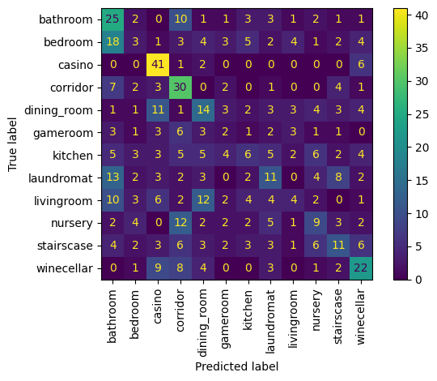

```
|---------------------------------|
|----- SVM: model_svm_150_2_4 -----|
|---------------------------------|

Model name: model_svm_150_2_4
Parameters Train: {'SVC__C': 0.000244140625, 'SVC__penalty': 'l2'}

Cohen's Kappa Train: 24.55
Balanced Accuracy Train: 30.80%
Accuracy Train: 30.83%

Cohen's Kappa Test: 26.45
Balanced Accuracy Test: 30.39%
Accuracy Test: 32.81%

Classification Report
              precision    recall  f1-score   support

    bathroom       0.31      0.58      0.40        50
     bedroom       0.20      0.14      0.16        50
      casino       0.36      0.88      0.51        50
    corridor       0.40      0.60      0.48        50
 dining_room       0.31      0.24      0.27        50
    gameroom       0.14      0.04      0.06        26
     kitchen       0.29      0.12      0.17        50
  laundromat       0.48      0.20      0.28        50
  livingroom       0.23      0.12      0.16        50
     nursery       0.20      0.18      0.19        44
  stairscase       0.31      0.22      0.26        50
  winecellar       0.43      0.46      0.45        50

    accuracy                           0.33       570
   macro avg       0.30      0.32      0.28       570
weighted avg       0.31      0.33      0.29       570

Confusion Matrix:
```

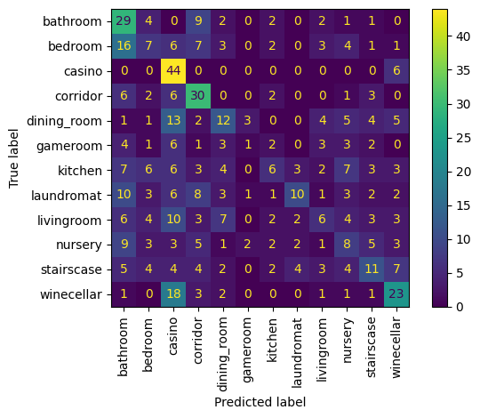

```
|---------------------------------|
|----- SVM: model_svm_50_4_8 -----|
|---------------------------------|

Model name: model_svm_50_4_8
Parameters Train: {'SVC__C': 0.0039062500000000095, 'SVC__penalty': 'l2'}

Cohen's Kappa Train: 25.1
Balanced Accuracy Train: 31.29%
Accuracy Train: 31.33%

Cohen's Kappa Test: 26.87
Balanced Accuracy Test: 28.98%
Accuracy Test: 33.16%

Classification Report
              precision    recall  f1-score   support

    bathroom       0.33      0.54      0.41        50
     bedroom       0.30      0.26      0.28        50
      casino       0.43      0.84      0.57        50
    corridor       0.40      0.54      0.46        50
 dining_room       0.31      0.28      0.29        50
    gameroom       0.23      0.12      0.15        26
     kitchen       0.14      0.06      0.08        50
  laundromat       0.26      0.22      0.24        50
  livingroom       0.12      0.04      0.06        50
     nursery       0.24      0.23      0.24        44
  stairscase       0.30      0.22      0.25        50
  winecellar       0.42      0.52      0.46        50

    accuracy                           0.33       570
   macro avg       0.29      0.32      0.29       570
weighted avg       0.29      0.33      0.30       570

Confusion Matrix:
```

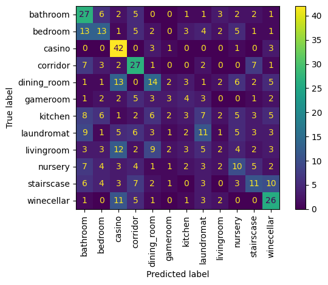

```
|---------------------------------|
|----- SVM: model_svm_150_4_8 -----|
|---------------------------------|

Model name: model_svm_150_4_8
Parameters Train: {'SVC__C': 0.000244140625, 'SVC__penalty': 'l2'}

Cohen's Kappa Train: 26.82
Balanced Accuracy Train: 32.86%
Accuracy Train: 32.92%

Cohen's Kappa Test: 29.69
Balanced Accuracy Test: 33.68%
Accuracy Test: 35.79%

Classification Report
              precision    recall  f1-score   support

    bathroom       0.31      0.56      0.40        50
     bedroom       0.27      0.20      0.23        50
      casino       0.40      0.86      0.54        50
    corridor       0.39      0.60      0.47        50
 dining_room       0.36      0.24      0.29        50
    gameroom       0.29      0.08      0.12        26
     kitchen       0.22      0.12      0.16        50
  laundromat       0.37      0.42      0.39        50
  livingroom       0.30      0.12      0.17        50
     nursery       0.39      0.20      0.27        44
  stairscase       0.26      0.16      0.20        50
  winecellar       0.48      0.58      0.53        50

    accuracy                           0.36       570
   macro avg       0.34      0.35      0.31       570
weighted avg       0.34      0.36      0.32       570

Confusion Matrix:
```

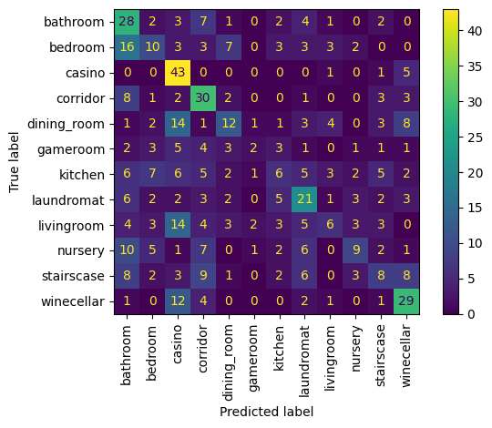

```
|---------------------------------|
|----- SVM: model_svm_50_6_12 -----|
|---------------------------------|

Model name: model_svm_50_6_12
Parameters Train: {'SVC__C': 0.0039062500000000095, 'SVC__penalty': 'l2'}

Cohen's Kappa Train: 25.0
Balanced Accuracy Train: 31.26%
Accuracy Train: 31.25%

Cohen's Kappa Test: 27.48
Balanced Accuracy Test: 29.06%
Accuracy Test: 33.68%

Classification Report
              precision    recall  f1-score   support

    bathroom       0.35      0.54      0.42        50
     bedroom       0.36      0.16      0.22        50
      casino       0.44      0.88      0.58        50
    corridor       0.40      0.66      0.50        50
 dining_room       0.22      0.18      0.20        50
    gameroom       0.00      0.00      0.00        26
     kitchen       0.35      0.18      0.24        50
  laundromat       0.29      0.34      0.31        50
  livingroom       0.04      0.02      0.03        50
     nursery       0.25      0.25      0.25        44
  stairscase       0.32      0.12      0.17        50
  winecellar       0.47      0.54      0.50        50

    accuracy                           0.34       570
   macro avg       0.29      0.32      0.29       570
weighted avg       0.30      0.34      0.30       570

Confusion Matrix:
```

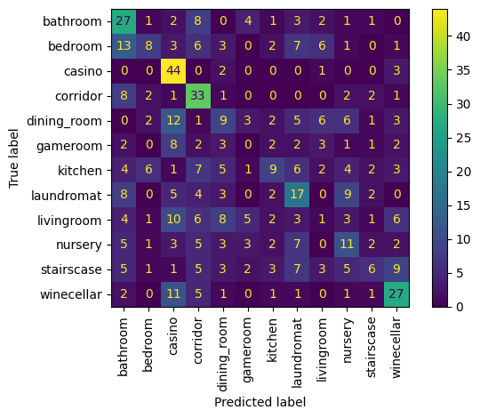

```
|---------------------------------|
|----- SVM: model_svm_150_6_12 -----|
|---------------------------------|

Model name: model_svm_150_6_12
Parameters Train: {'SVC__C': 0.000244140625, 'SVC__penalty': 'l2'}

Cohen's Kappa Train: 25.73
Balanced Accuracy Train: 31.88%
Accuracy Train: 31.92%

Cohen's Kappa Test: 27.96
Balanced Accuracy Test: 28.98%
Accuracy Test: 34.21%

Classification Report
              precision    recall  f1-score   support

    bathroom       0.33      0.64      0.44        50
     bedroom       0.17      0.08      0.11        50
      casino       0.44      0.90      0.59        50
    corridor       0.40      0.64      0.49        50
 dining_room       0.21      0.18      0.19        50
    gameroom       0.00      0.00      0.00        26
     kitchen       0.27      0.16      0.20        50
  laundromat       0.35      0.36      0.36        50
  livingroom       0.16      0.08      0.11        50
     nursery       0.41      0.27      0.33        44
  stairscase       0.36      0.16      0.22        50
  winecellar       0.38      0.46      0.42        50

    accuracy                           0.34       570
   macro avg       0.29      0.33      0.29       570
weighted avg       0.30      0.34      0.30       570

Confusion Matrix:
```

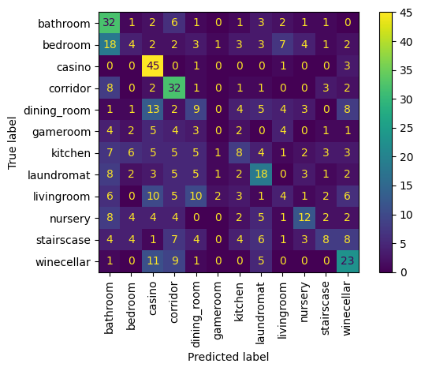

```python
model = [model_svm_50_2_4, model_svm_150_2_4, model_svm_50_4_8, model_svm_150_4_8, model_svm_50_6_12, model_svm_150_6_12]
model_names = ['model_svm_50_2_4', 'model_svm_150_2_4', 'model_svm_50_4_8', 'model_svm_150_4_8', 'model_svm_50_6_12', 'model_svm_150_6_12']
List_test_data = [test_50_2_4, test_150_2_4, test_50_4_8, test_150_4_8, test_50_6_12, test_150_6_12]

for model_ML, model_name, test_ds in zip(model, model_names, List_test_data):
    y_hat = model_ML.predict(test_ds)
    labels = np.unique(y_test)
    conf_matrix = confusion_matrix(y_hat, y_test, labels=labels)
    mean_balanced_accuracy_score = model_ML.cv_results_['mean_test_balanced_accuracy_score'][model_ML.best_index_]
    mean_accuracy = model_ML.cv_results_['mean_test_accuracy'][model_ML.best_index_]

    accuracy = accuracy_score(y_hat, y_test)
    Balanced_accuracy = balanced_accuracy_score(y_hat, y_test)
    cohen_kappa = cohen_kappa_score(y_hat, y_test)

    print()
    print('|---------------------------------|')
    print(f'|----- SVM: {model_name} -----|')
    print('|---------------------------------|')
    print()
    print(f"Model name: {model_name}")
    print(f"Parameters Train: {model_ML.best_params_}")
    print()
    print(f"Cohen\'s Kappa Train: {round(model_ML.best_score_ * 100, 2)}")
    print(f'Balanced Accuracy Train: {mean_balanced_accuracy_score * 100:.2f}%')
    print(f'Accuracy Train: {mean_accuracy * 100:.2f}%')
    print()
    print(f'Cohen\'s Kappa Test: {cohen_kappa*100:.2f}')
    print(f'Balanced Accuracy Test: {Balanced_accuracy * 100:.2f}%')
    print(f'Accuracy Test: {accuracy * 100:.2f}%')
    print()
    print('Classification Report')
    print(classification_report(y_test, y_hat, target_names=labels))
    print("Confusion Matrix:")
    ConfusionMatrixDisplay.from_predictions(y_test, y_hat, display_labels=labels, xticks_rotation="vertical")
    plt.tight_layout()
    plt.show()
    print()
```

# *SVM model with Data PCA*

```python
parameters = [
  {'SVC__C': 2.**np.arange(-12, 1, 0.8),
   'SVC__penalty': ['l1', 'l2']}
  ]

pca_svm_pipe = Pipeline(steps=[
                 ('scale', StandardScaler()),
                 ('SVC', LinearSVC(random_state=RANDOM_SEED, dual=False))
                 ])

pca_model_svm_50_2_4   = GridSearchCV(estimator = pca_svm_pipe, param_grid = parameters, refit='cohen_kappa_score', cv=kfold, scoring=scoring, n_jobs=-1 )
pca_model_svm_150_2_4  = GridSearchCV(estimator = pca_svm_pipe, param_grid = parameters, refit='cohen_kappa_score', cv=kfold, scoring=scoring, n_jobs=-1 )
pca_model_svm_50_4_8   = GridSearchCV(estimator = pca_svm_pipe, param_grid = parameters, refit='cohen_kappa_score', cv=kfold, scoring=scoring, n_jobs=-1 )
pca_model_svm_150_4_8  = GridSearchCV(estimator = pca_svm_pipe, param_grid = parameters, refit='cohen_kappa_score', cv=kfold, scoring=scoring, n_jobs=-1 )
pca_model_svm_50_6_12  = GridSearchCV(estimator = pca_svm_pipe, param_grid = parameters, refit='cohen_kappa_score', cv=kfold, scoring=scoring, n_jobs=-1 )
pca_model_svm_150_6_12 = GridSearchCV(estimator = pca_svm_pipe, param_grid = parameters, refit='cohen_kappa_score', cv=kfold, scoring=scoring, n_jobs=-1 )
```

#### **Fit model**

```python
pca_model_svm_50_2_4.fit(pca_train_50_2_4, y_train)
pca_model_svm_150_2_4.fit(pca_train_150_2_4, y_train)
pca_model_svm_50_4_8.fit(pca_train_50_4_8, y_train)
pca_model_svm_150_4_8.fit(pca_train_150_4_8, y_train)
pca_model_svm_50_6_12.fit(pca_train_50_6_12, y_train)
pca_model_svm_150_6_12.fit(pca_train_150_6_12, y_train)
```

```
GridSearchCV(cv=StratifiedKFold(n_splits=6, random_state=123, shuffle=True),
             estimator=Pipeline(steps=[('scale', StandardScaler()),
                                       ('SVC',
                                        LinearSVC(dual=False,
                                                  random_state=123))]),
             n_jobs=-1,
             param_grid=[{'SVC__C': array([2.44140625e-04, 4.25073517e-04, 7.40095980e-04, 1.28858194e-03,
       2.24355147e-03, 3.90625000e-03, 6.80117628e-03, 1.18415357e-02,
       2.06173111e-02, 3.58968236e-02, 6.25000000e-02, 1.08818820e-01,
       1.89464571e-01, 3.29876978e-01, 5.74349177e-01, 1.00000000e+00,
       1.74110113e+00]),
                          'SVC__penalty': ['l1', 'l2']}],
             refit='cohen_kappa_score',
             scoring={'accuracy': make_scorer(accuracy_score),
                      'balanced_accuracy_score': make_scorer(balanced_accuracy_score),
                      'cohen_kappa_score': make_scorer(cohen_kappa_score)})
```

#### **Results models**

```
|---------------------------------|
|----- SVM: pca_model_svm_50_2_4 -----|
|---------------------------------|

Model name: pca_model_svm_50_2_4
Parameters Train: {'SVC__C': 0.0625000000000003, 'SVC__penalty': 'l1'}

Cohen's Kappa Train: 11.45
Balanced Accuracy Train: 18.80%
Accuracy Train: 18.83%

Cohen's Kappa Test: 13.00
Balanced Accuracy Test: 15.04%
Accuracy Test: 20.53%

Classification Report
              precision    recall  f1-score   support

    bathroom       0.24      0.68      0.35        50
     bedroom       0.00      0.00      0.00        50
      casino       0.27      0.58      0.37        50
    corridor       0.18      0.24      0.21        50
 dining_room       0.14      0.16      0.15        50
    gameroom       0.09      0.04      0.05        26
     kitchen       0.00      0.00      0.00        50
  laundromat       0.18      0.04      0.07        50
  livingroom       0.17      0.06      0.09        50
     nursery       0.05      0.02      0.03        44
  stairscase       0.21      0.16      0.18        50
  winecellar       0.27      0.38      0.31        50

    accuracy                           0.21       570
   macro avg       0.15      0.20      0.15       570
weighted avg       0.15      0.21      0.16       570

Confusion Matrix:
```

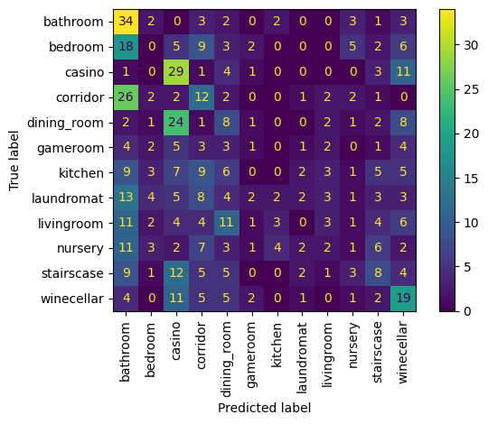

```
|---------------------------------|
|----- SVM: pca_model_svm_150_2_4 -----|
|---------------------------------|

Model name: pca_model_svm_150_2_4
Parameters Train: {'SVC__C': 0.000244140625, 'SVC__penalty': 'l2'}

Cohen's Kappa Train: 9.99
Balanced Accuracy Train: 17.50%
Accuracy Train: 17.50%

Cohen's Kappa Test: 10.75
Balanced Accuracy Test: 14.42%
Accuracy Test: 18.42%

Classification Report
              precision    recall  f1-score   support

    bathroom       0.19      0.54      0.28        50
     bedroom       0.08      0.04      0.05        50
      casino       0.26      0.56      0.35        50
    corridor       0.14      0.16      0.15        50
 dining_room       0.02      0.02      0.02        50
    gameroom       0.11      0.08      0.09        26
     kitchen       0.26      0.12      0.16        50
  laundromat       0.00      0.00      0.00        50
  livingroom       0.18      0.08      0.11        50
     nursery       0.05      0.02      0.03        44
  stairscase       0.15      0.08      0.11        50
  winecellar       0.29      0.44      0.35        50

    accuracy                           0.18       570
   macro avg       0.14      0.18      0.14       570
weighted avg       0.15      0.18      0.15       570

Confusion Matrix:
```

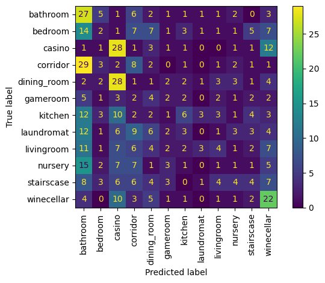

```
|---------------------------------|
|----- SVM: pca_model_svm_50_4_8 -----|
|---------------------------------|

Model name: pca_model_svm_50_4_8
Parameters Train: {'SVC__C': 0.0625000000000003, 'SVC__penalty': 'l1'}

Cohen's Kappa Train: 10.83
Balanced Accuracy Train: 18.26%
Accuracy Train: 18.25%

Cohen's Kappa Test: 10.74
Balanced Accuracy Test: 15.60%
Accuracy Test: 18.42%

Classification Report
              precision    recall  f1-score   support

    bathroom       0.21      0.62      0.32        50
     bedroom       0.22      0.08      0.12        50
      casino       0.24      0.40      0.30        50
    corridor       0.14      0.16      0.15        50
 dining_room       0.18      0.18      0.18        50
    gameroom       0.11      0.08      0.09        26
     kitchen       0.04      0.02      0.03        50
  laundromat       0.06      0.02      0.03        50
  livingroom       0.14      0.08      0.10        50
     nursery       0.15      0.05      0.07        44
  stairscase       0.17      0.08      0.11        50
  winecellar       0.21      0.38      0.27        50

    accuracy                           0.18       570
   macro avg       0.16      0.18      0.15       570
weighted avg       0.16      0.18      0.15       570

Confusion Matrix:
```

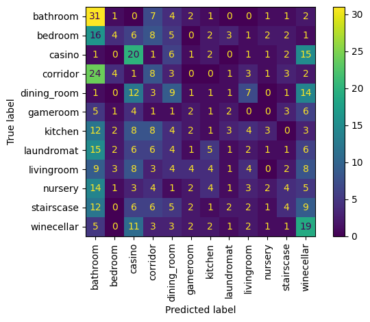

```
|---------------------------------|
|----- SVM: pca_model_svm_150_4_8 -----|
|---------------------------------|

Model name: pca_model_svm_150_4_8
Parameters Train: {'SVC__C': 0.020617311105826555, 'SVC__penalty': 'l1'}

Cohen's Kappa Train: 9.19
Balanced Accuracy Train: 16.74%
Accuracy Train: 16.75%

Cohen's Kappa Test: 9.74
Balanced Accuracy Test: 13.08%
Accuracy Test: 17.54%

Classification Report
              precision    recall  f1-score   support

    bathroom       0.19      0.64      0.29        50
     bedroom       0.08      0.04      0.05        50
      casino       0.25      0.56      0.35        50
    corridor       0.12      0.14      0.13        50
 dining_room       0.17      0.12      0.14        50
    gameroom       0.07      0.04      0.05        26
     kitchen       0.21      0.06      0.09        50
  laundromat       0.00      0.00      0.00        50
  livingroom       0.10      0.02      0.03        50
     nursery       0.14      0.05      0.07        44
  stairscase       0.05      0.02      0.03        50
  winecellar       0.18      0.34      0.24        50

    accuracy                           0.18       570
   macro avg       0.13      0.17      0.12       570
weighted avg       0.13      0.18      0.13       570

Confusion Matrix:
```

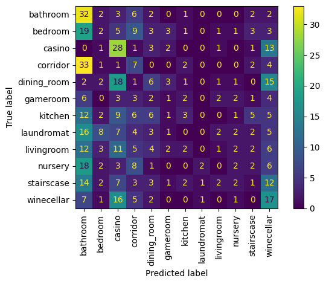

```
|---------------------------------|
|----- SVM: pca_model_svm_50_6_12 -----|
|---------------------------------|

Model name: pca_model_svm_50_6_12
Parameters Train: {'SVC__C': 0.000740095979741406, 'SVC__penalty': 'l2'}

Cohen's Kappa Train: 10.45
Balanced Accuracy Train: 17.89%
Accuracy Train: 17.92%

Cohen's Kappa Test: 7.48
Balanced Accuracy Test: 10.34%
Accuracy Test: 15.44%

Classification Report
              precision    recall  f1-score   support

    bathroom       0.21      0.64      0.32        50
     bedroom       0.04      0.02      0.03        50
      casino       0.23      0.50      0.31        50
    corridor       0.07      0.04      0.05        50
 dining_room       0.11      0.06      0.08        50
    gameroom       0.07      0.04      0.05        26
     kitchen       0.13      0.04      0.06        50
  laundromat       0.03      0.02      0.03        50
  livingroom       0.10      0.04      0.06        50
     nursery       0.03      0.02      0.02        44
  stairscase       0.00      0.00      0.00        50
  winecellar       0.22      0.36      0.27        50

    accuracy                           0.15       570
   macro avg       0.10      0.15      0.11       570
weighted avg       0.11      0.15      0.11       570

Confusion Matrix:
```

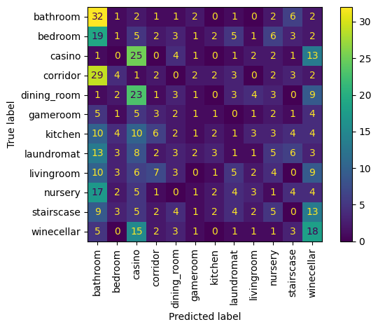

```
|---------------------------------|
|----- SVM: pca_model_svm_150_6_12 -----|
|---------------------------------|

Model name: pca_model_svm_150_6_12
Parameters Train: {'SVC__C': 0.000244140625, 'SVC__penalty': 'l2'}

Cohen's Kappa Train: 10.09
Balanced Accuracy Train: 17.59%
Accuracy Train: 17.58%

Cohen's Kappa Test: 13.42
Balanced Accuracy Test: 17.78%
Accuracy Test: 20.88%

Classification Report
              precision    recall  f1-score   support

    bathroom       0.21      0.62      0.31        50
     bedroom       0.33      0.10      0.15        50
      casino       0.25      0.44      0.32        50
    corridor       0.19      0.20      0.19        50
 dining_room       0.20      0.24      0.22        50
    gameroom       0.12      0.08      0.10        26
     kitchen       0.19      0.08      0.11        50
  laundromat       0.00      0.00      0.00        50
  livingroom       0.09      0.06      0.07        50
     nursery       0.18      0.09      0.12        44
  stairscase       0.06      0.02      0.03        50
  winecellar       0.31      0.50      0.38        50

    accuracy                           0.21       570
   macro avg       0.18      0.20      0.17       570
weighted avg       0.18      0.21      0.17       570

Confusion Matrix:
```

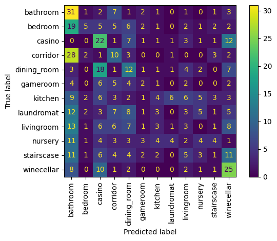

```python
model = [pca_model_svm_50_2_4, pca_model_svm_150_2_4, pca_model_svm_50_4_8, pca_model_svm_150_4_8, pca_model_svm_50_6_12, pca_model_svm_150_6_12]
model_names = ['pca_model_svm_50_2_4', 'pca_model_svm_150_2_4', 'pca_model_svm_50_4_8', 'pca_model_svm_150_4_8', 'pca_model_svm_50_6_12', 'pca_model_svm_150_6_12']
List_test_data = [pca_test_50_2_4, pca_test_150_2_4, pca_test_50_4_8, pca_test_150_4_8, pca_test_50_6_12, pca_test_150_6_12]

for model_ML, model_name, test_ds in zip(model, model_names, List_test_data):
    y_hat = model_ML.predict(test_ds)
    labels = np.unique(y_test)
    conf_matrix = confusion_matrix(y_hat, y_test, labels=labels)
    mean_balanced_accuracy_score = model_ML.cv_results_['mean_test_balanced_accuracy_score'][model_ML.best_index_]
    mean_accuracy = model_ML.cv_results_['mean_test_accuracy'][model_ML.best_index_]

    accuracy = accuracy_score(y_hat, y_test)
    Balanced_accuracy = balanced_accuracy_score(y_hat, y_test)
    cohen_kappa = cohen_kappa_score(y_hat, y_test)

    print()
    print('|---------------------------------|')
    print(f'|----- SVM: {model_name} -----|')
    print('|---------------------------------|')
    print()
    print(f"Model name: {model_name}")
    print(f"Parameters Train: {model_ML.best_params_}")
    print()
    print(f"Cohen\'s Kappa Train: {round(model_ML.best_score_ * 100, 2)}")
    print(f'Balanced Accuracy Train: {mean_balanced_accuracy_score * 100:.2f}%')
    print(f'Accuracy Train: {mean_accuracy * 100:.2f}%')
    print()
    print(f'Cohen\'s Kappa Test: {cohen_kappa*100:.2f}')
    print(f'Balanced Accuracy Test: {Balanced_accuracy * 100:.2f}%')
    print(f'Accuracy Test: {accuracy * 100:.2f}%')
    print()
    print('Classification Report')
    print(classification_report(y_test, y_hat, target_names=labels))
    print("Confusion Matrix:")
    ConfusionMatrixDisplay.from_predictions(y_test, y_hat, display_labels=labels, xticks_rotation="vertical")
    plt.tight_layout()
    plt.show()
    print()
```

# *SVM model using Fisher Vector*

```python
parameters = [
  {'SVC__C': 2.**np.arange(-12, 1, 0.8),
   'SVC__penalty': ['l1', 'l2'],
   'pca__n_components': [0.6, 0.7, 0.8]
   }
  ]

fv_svm_pipe = Pipeline(steps=[
                 ('scale', StandardScaler()),
                 ('pca', PCA(svd_solver = 'full', random_state=RANDOM_SEED)),
                 ('SVC', LinearSVC(random_state=RANDOM_SEED, dual=False))
                 ])

fv_model_svm_50_4_8   = GridSearchCV(estimator = fv_svm_pipe, param_grid = parameters, refit='cohen_kappa_score', cv=kfold, scoring=scoring, n_jobs=-1 )
fv_model_svm_150_4_8  = GridSearchCV(estimator = fv_svm_pipe, param_grid = parameters, refit='cohen_kappa_score', cv=kfold, scoring=scoring, n_jobs=-1 )
```

#### **Fit model**

```python
fv_model_svm_50_4_8.fit(FV_feat_train_50_4_8, y_train)
fv_model_svm_150_4_8.fit(FV_feat_train_150_4_8, y_train)
```

```
GridSearchCV(cv=StratifiedKFold(n_splits=6, random_state=123, shuffle=True),
             estimator=Pipeline(steps=[('scale', StandardScaler()),
                                       ('pca',
                                        PCA(random_state=123,
                                            svd_solver='full')),
                                       ('SVC',
                                        LinearSVC(dual=False,
                                                  random_state=123))]),
             n_jobs=-1,
             param_grid=[{'SVC__C': array([2.44140625e-04, 4.25073517e-04, 7.40095980e-04, 1.28858194e-03,
       2.24355147e-03, 3.90625000e-...
       2.06173111e-02, 3.58968236e-02, 6.25000000e-02, 1.08818820e-01,
       1.89464571e-01, 3.29876978e-01, 5.74349177e-01, 1.00000000e+00,
       1.74110113e+00]),
                          'SVC__penalty': ['l1', 'l2'],
                          'pca__n_components': [0.6, 0.7, 0.8]}],
             refit='cohen_kappa_score',
             scoring={'accuracy': make_scorer(accuracy_score),
                      'balanced_accuracy_score': make_scorer(balanced_accuracy_score),
                      'cohen_kappa_score': make_scorer(cohen_kappa_score)})
```

#### **Results models**

```
|---------------------------------|
|----- SVM: fv_model_svm_50_4_8 -----|
|---------------------------------|

Model name: fv_model_svm_50_4_8
Parameters Train: {'SVC__C': 0.020617311105826555, 'SVC__penalty': 'l1', 'pca__n_components': 0.8}

Cohen's Kappa Train: 19.91
Balanced Accuracy Train: 26.57%
Accuracy Train: 26.58%

Cohen's Kappa Test: 18.67
Balanced Accuracy Test: 22.37%
Accuracy Test: 25.61%

Classification Report
              precision    recall  f1-score   support

    bathroom       0.22      0.22      0.22        50
     bedroom       0.07      0.06      0.07        50
      casino       0.44      0.76      0.55        50
    corridor       0.41      0.52      0.46        50
 dining_room       0.26      0.20      0.23        50
    gameroom       0.22      0.19      0.20        26
     kitchen       0.14      0.10      0.11        50
  laundromat       0.20      0.24      0.22        50
  livingroom       0.07      0.04      0.05        50
     nursery       0.14      0.11      0.12        44
  stairscase       0.21      0.16      0.18        50
  winecellar       0.31      0.42      0.36        50

    accuracy                           0.26       570
   macro avg       0.22      0.25      0.23       570
weighted avg       0.22      0.26      0.23       570

Confusion Matrix:
```

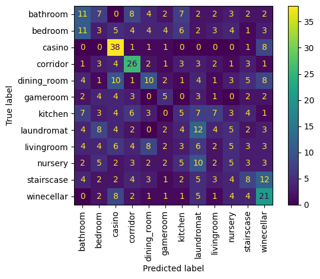

```
|---------------------------------|
|----- SVM: fv_model_svm_150_4_8 -----|
|---------------------------------|

Model name: fv_model_svm_150_4_8
Parameters Train: {'SVC__C': 0.011841535675862526, 'SVC__penalty': 'l2', 'pca__n_components': 0.8}

Cohen's Kappa Train: 14.28
Balanced Accuracy Train: 21.43%
Accuracy Train: 21.42%

Cohen's Kappa Test: 17.98
Balanced Accuracy Test: 22.82%
Accuracy Test: 24.91%

Classification Report
              precision    recall  f1-score   support

    bathroom       0.27      0.26      0.26        50
     bedroom       0.22      0.16      0.19        50
      casino       0.41      0.70      0.51        50
    corridor       0.20      0.24      0.22        50
 dining_room       0.25      0.18      0.21        50
    gameroom       0.16      0.19      0.18        26
     kitchen       0.13      0.12      0.12        50
  laundromat       0.22      0.24      0.23        50
  livingroom       0.22      0.10      0.14        50
     nursery       0.17      0.20      0.19        44
  stairscase       0.14      0.08      0.10        50
  winecellar       0.35      0.48      0.40        50

    accuracy                           0.25       570
   macro avg       0.23      0.25      0.23       570
weighted avg       0.23      0.25      0.23       570

Confusion Matrix:
```

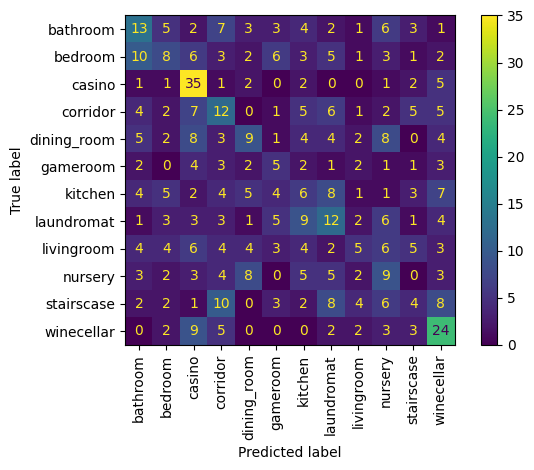

```python
model = [fv_model_svm_50_4_8, fv_model_svm_150_4_8]
model_names = ['fv_model_svm_50_4_8', 'fv_model_svm_150_4_8']
List_test_data = [FV_feat_test_50_4_8, FV_feat_test_150_4_8]


for model_ML, model_name, test_ds in zip(model, model_names, List_test_data):
    y_hat = model_ML.predict(test_ds)
    labels = np.unique(y_test)
    conf_matrix = confusion_matrix(y_hat, y_test, labels=labels)
    mean_balanced_accuracy_score = model_ML.cv_results_['mean_test_balanced_accuracy_score'][model_ML.best_index_]
    mean_accuracy = model_ML.cv_results_['mean_test_accuracy'][model_ML.best_index_]

    accuracy = accuracy_score(y_hat, y_test)
    Balanced_accuracy = balanced_accuracy_score(y_hat, y_test)
    cohen_kappa = cohen_kappa_score(y_hat, y_test)

    print()
    print('|---------------------------------|')
    print(f'|----- SVM: {model_name} -----|')
    print('|---------------------------------|')
    print()
    print(f"Model name: {model_name}")
    print(f"Parameters Train: {model_ML.best_params_}")
    print()
    print(f"Cohen\'s Kappa Train: {round(model_ML.best_score_ * 100, 2)}")
    print(f'Balanced Accuracy Train: {mean_balanced_accuracy_score * 100:.2f}%')
    print(f'Accuracy Train: {mean_accuracy * 100:.2f}%')
    print()
    print(f'Cohen\'s Kappa Test: {cohen_kappa*100:.2f}')
    print(f'Balanced Accuracy Test: {Balanced_accuracy * 100:.2f}%')
    print(f'Accuracy Test: {accuracy * 100:.2f}%')
    print()
    print('Classification Report')
    print(classification_report(y_test, y_hat, target_names=labels))
    print("Confusion Matrix:")
    ConfusionMatrixDisplay.from_predictions(y_test, y_hat, display_labels=labels, xticks_rotation="vertical")
    plt.tight_layout()
    plt.show()
    print()
```

# *SVM model using Dense feature*

```python
parameters = [
  {'SVC__C': 2.**np.arange(-2, 12, 0.8),
   'SVC__penalty': ['l1', 'l2'],
   }
  ]

svm_pipe = Pipeline(steps=[
                 ('scale', StandardScaler()),
                 ('SVC', LinearSVC(random_state=RANDOM_SEED, dual=False))
                 ])

model_svm_dense   = GridSearchCV(estimator = svm_pipe, param_grid = parameters, refit='cohen_kappa_score', cv=kfold, scoring=scoring, n_jobs=-1 )
```

#### **Fit model**

```python
model_svm_dense.fit(feat_train, y_train)
```

```
GridSearchCV(cv=StratifiedKFold(n_splits=6, random_state=123, shuffle=True),
             estimator=Pipeline(steps=[('scale', StandardScaler()),
                                       ('SVC',
                                        LinearSVC(dual=False,
                                                  random_state=123))]),
             n_jobs=-1,
             param_grid=[{'SVC__C': array([2.50000000e-01, 4.35275282e-01, 7.57858283e-01, 1.31950791e+00,
       2.29739671e+00, 4.00000000e+00, 6.96440451e+00, 1.21257325e+01,
       2.11121266e+01,...83474e+01, 6.40000000e+01, 1.11430472e+02,
       1.94011721e+02, 3.37794025e+02, 5.88133558e+02, 1.02400000e+03,
       1.78288755e+03, 3.10418753e+03]),
                          'SVC__penalty': ['l1', 'l2']}],
             refit='cohen_kappa_score',
             scoring={'accuracy': make_scorer(accuracy_score),
                      'balanced_accuracy_score': make_scorer(balanced_accuracy_score),
                      'cohen_kappa_score': make_scorer(cohen_kappa_score)})
```

#### **Results models**

```
|---------------------------------|
|----- SVM: model_svm_dense -----|
|---------------------------------|

Model name: model_svm_dense
Parameters Train: {'SVC__C': 6.9644045063689966, 'SVC__penalty': 'l2'}

Cohen's Kappa Train: 33.37
Balanced Accuracy Train: 38.91%
Accuracy Train: 38.92%

Cohen's Kappa Test: 35.69
Balanced Accuracy Test: 39.25%
Accuracy Test: 41.05%

Classification Report
              precision    recall  f1-score   support

    bathroom       0.57      0.58      0.57        50
     bedroom       0.33      0.26      0.29        50
      casino       0.57      0.60      0.58        50
    corridor       0.54      0.58      0.56        50
 dining_room       0.37      0.30      0.33        50
    gameroom       0.21      0.35      0.26        26
     kitchen       0.27      0.20      0.23        50
  laundromat       0.40      0.38      0.39        50
  livingroom       0.29      0.08      0.12        50
     nursery       0.40      0.55      0.46        44
  stairscase       0.30      0.34      0.32        50
  winecellar       0.48      0.70      0.57        50

    accuracy                           0.41       570
   macro avg       0.39      0.41      0.39       570
weighted avg       0.40      0.41      0.40       570

Confusion Matrix:
```

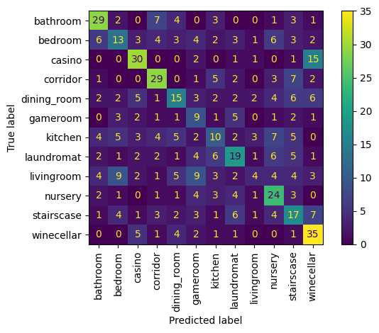

```python
model = [model_svm_dense]
model_names = ['model_svm_dense']
List_test_data = [feat_test]

for model_ML, model_name, test_ds in zip(model, model_names, List_test_data):
    y_hat = model_ML.predict(test_ds)
    labels = np.unique(y_test)
    conf_matrix = confusion_matrix(y_hat, y_test, labels=labels)
    mean_balanced_accuracy_score = model_ML.cv_results_['mean_test_balanced_accuracy_score'][model_ML.best_index_]
    mean_accuracy = model_ML.cv_results_['mean_test_accuracy'][model_ML.best_index_]

    accuracy = accuracy_score(y_hat, y_test)
    Balanced_accuracy = balanced_accuracy_score(y_hat, y_test)
    cohen_kappa = cohen_kappa_score(y_hat, y_test)

    print()
    print('|---------------------------------|')
    print(f'|----- SVM: {model_name} -----|')
    print('|---------------------------------|')
    print()
    print(f"Model name: {model_name}")
    print(f"Parameters Train: {model_ML.best_params_}")
    print()
    print(f"Cohen\'s Kappa Train: {round(model_ML.best_score_ * 100, 2)}")
    print(f'Balanced Accuracy Train: {mean_balanced_accuracy_score * 100:.2f}%')
    print(f'Accuracy Train: {mean_accuracy * 100:.2f}%')
    print()
    print(f'Cohen\'s Kappa Test: {cohen_kappa*100:.2f}')
    print(f'Balanced Accuracy Test: {Balanced_accuracy * 100:.2f}%')
    print(f'Accuracy Test: {accuracy * 100:.2f}%')
    print()
    print('Classification Report')
    print(classification_report(y_test, y_hat, target_names=labels))
    print("Confusion Matrix:")
    ConfusionMatrixDisplay.from_predictions(y_test, y_hat, display_labels=labels, xticks_rotation="vertical")
    plt.tight_layout()
    plt.show()
    print()
```

# *SVM model using Dense feature and Keypoints*

#### **Concatenate the DataSet Dense and Keypoints**

```python
des_train_50_2_4 = np.concatenate([train_50_2_4, feat_train], axis = 1)
des_test_50_2_4 = np.concatenate([test_50_2_4, feat_test], axis = 1)

des_train_150_2_4 = np.concatenate([train_150_2_4, feat_train], axis = 1)
des_test_150_2_4 = np.concatenate([test_150_2_4, feat_test], axis = 1)

des_train_50_4_8 = np.concatenate([train_50_4_8, feat_train], axis = 1)
des_test_50_4_8 = np.concatenate([test_50_4_8, feat_test], axis = 1)

des_train_150_4_8 = np.concatenate([train_150_4_8, feat_train], axis = 1)
des_test_150_4_8 = np.concatenate([test_150_4_8, feat_test], axis = 1)

des_train_50_6_12 = np.concatenate([train_50_6_12, feat_train], axis = 1)
des_test_50_6_12 = np.concatenate([test_50_6_12, feat_test], axis = 1)

des_train_150_6_12 = np.concatenate([train_150_6_12, feat_train], axis = 1)
des_test_150_6_12 = np.concatenate([test_150_6_12, feat_test], axis = 1)
```

#### **Model**

```python
parameters = [
  {'SVC__C': 2.**np.arange(-2, 12, 0.8),
   'SVC__penalty': ['l1', 'l2'],
   }
  ]

svm_pipe = Pipeline(steps=[
                 ('scale', StandardScaler()),
                 ('SVC', LinearSVC(random_state=RANDOM_SEED, dual=False))
                 ])

model_svm_dense_key_50_2_4    = GridSearchCV(estimator = svm_pipe, param_grid = parameters, refit='cohen_kappa_score', cv=kfold, scoring=scoring, n_jobs=-1 )
model_svm_dense_key_150_2_4   = GridSearchCV(estimator = svm_pipe, param_grid = parameters, refit='cohen_kappa_score', cv=kfold, scoring=scoring, n_jobs=-1 )
model_svm_dense_key_50_4_8    = GridSearchCV(estimator = svm_pipe, param_grid = parameters, refit='cohen_kappa_score', cv=kfold, scoring=scoring, n_jobs=-1 )
model_svm_dense_key_150_4_8   = GridSearchCV(estimator = svm_pipe, param_grid = parameters, refit='cohen_kappa_score', cv=kfold, scoring=scoring, n_jobs=-1 )
model_svm_dense_key_50_6_12   = GridSearchCV(estimator = svm_pipe, param_grid = parameters, refit='cohen_kappa_score', cv=kfold, scoring=scoring, n_jobs=-1 )
model_svm_dense_key_150_6_12  = GridSearchCV(estimator = svm_pipe, param_grid = parameters, refit='cohen_kappa_score', cv=kfold, scoring=scoring, n_jobs=-1 )
```

#### **Fit model**

```python
model_svm_dense_key_50_2_4.fit(des_train_50_2_4, y_train)
model_svm_dense_key_150_2_4.fit(des_train_150_2_4, y_train)
model_svm_dense_key_50_4_8.fit(des_train_50_4_8, y_train)
model_svm_dense_key_150_4_8.fit(des_train_150_4_8, y_train)
model_svm_dense_key_50_6_12.fit(des_train_50_6_12, y_train)
model_svm_dense_key_150_6_12.fit(des_train_150_6_12, y_train)
```

```
GridSearchCV(cv=StratifiedKFold(n_splits=6, random_state=123, shuffle=True),
             estimator=Pipeline(steps=[('scale', StandardScaler()),
                                       ('SVC',
                                        LinearSVC(dual=False,
                                                  random_state=123))]),
             n_jobs=-1,
             param_grid=[{'SVC__C': array([2.50000000e-01, 4.35275282e-01, 7.57858283e-01, 1.31950791e+00,
       2.29739671e+00, 4.00000000e+00, 6.96440451e+00, 1.21257325e+01,
       2.11121266e+01,...83474e+01, 6.40000000e+01, 1.11430472e+02,
       1.94011721e+02, 3.37794025e+02, 5.88133558e+02, 1.02400000e+03,
       1.78288755e+03, 3.10418753e+03]),
                          'SVC__penalty': ['l1', 'l2']}],
             refit='cohen_kappa_score',
             scoring={'accuracy': make_scorer(accuracy_score),
                      'balanced_accuracy_score': make_scorer(balanced_accuracy_score),
                      'cohen_kappa_score': make_scorer(cohen_kappa_score)})
```

#### **Results models**

```
|---------------------------------|
|----- SVM: model_svm_dense_key_50_2_4 -----|
|---------------------------------|

Model name: model_svm_dense_key_50_2_4
Parameters Train: {'SVC__C': 0.25, 'SVC__penalty': 'l1'}

Cohen's Kappa Train: 32.64
Balanced Accuracy Train: 38.23%
Accuracy Train: 38.25%

Cohen's Kappa Test: 35.66
Balanced Accuracy Test: 38.74%
Accuracy Test: 41.05%

Classification Report
              precision    recall  f1-score   support

    bathroom       0.51      0.64      0.57        50
     bedroom       0.25      0.16      0.20        50
      casino       0.64      0.70      0.67        50
    corridor       0.58      0.56      0.57        50
 dining_room       0.31      0.28      0.29        50
    gameroom       0.21      0.31      0.25        26
     kitchen       0.26      0.22      0.24        50
  laundromat       0.35      0.34      0.34        50
  livingroom       0.29      0.12      0.17        50
     nursery       0.41      0.52      0.46        44
  stairscase       0.35      0.38      0.37        50
  winecellar       0.49      0.66      0.56        50

    accuracy                           0.41       570
   macro avg       0.39      0.41      0.39       570
weighted avg       0.39      0.41      0.40       570

Confusion Matrix:
```

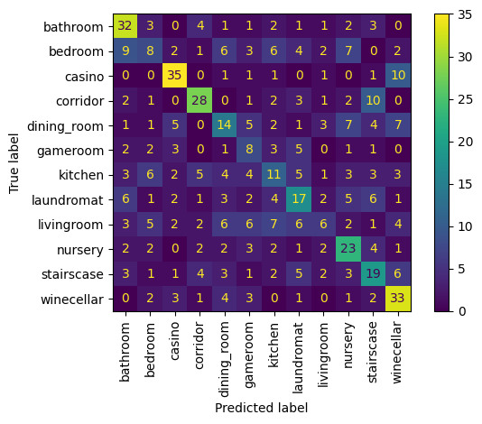

```
|---------------------------------|
|----- SVM: model_svm_dense_key_150_2_4 -----|
|---------------------------------|

Model name: model_svm_dense_key_150_2_4
Parameters Train: {'SVC__C': 0.25, 'SVC__penalty': 'l1'}

Cohen's Kappa Train: 25.92
Balanced Accuracy Train: 32.10%
Accuracy Train: 32.08%

Cohen's Kappa Test: 31.86
Balanced Accuracy Test: 36.82%
Accuracy Test: 37.54%

Classification Report
              precision    recall  f1-score   support

    bathroom       0.42      0.38      0.40        50
     bedroom       0.26      0.28      0.27        50
      casino       0.74      0.70      0.72        50
    corridor       0.50      0.52      0.51        50
 dining_room       0.30      0.26      0.28        50
    gameroom       0.15      0.27      0.19        26
     kitchen       0.26      0.22      0.24        50
  laundromat       0.48      0.42      0.45        50
  livingroom       0.07      0.06      0.07        50
     nursery       0.36      0.39      0.37        44
  stairscase       0.34      0.36      0.35        50
  winecellar       0.52      0.60      0.56        50

    accuracy                           0.38       570
   macro avg       0.37      0.37      0.37       570
weighted avg       0.38      0.38      0.37       570

Confusion Matrix:
```

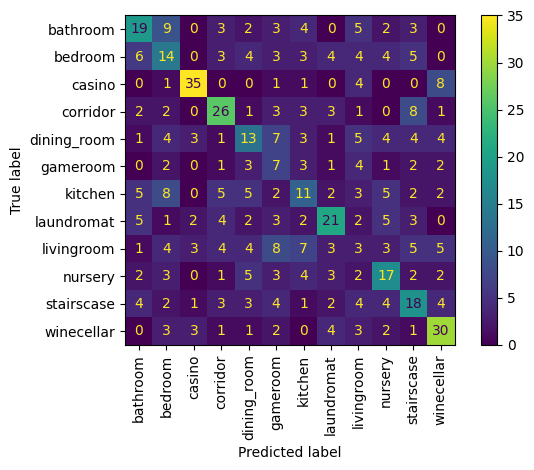

```
|---------------------------------|
|----- SVM: model_svm_dense_key_50_4_8 -----|
|---------------------------------|

Model name: model_svm_dense_key_50_4_8
Parameters Train: {'SVC__C': 0.43527528164806206, 'SVC__penalty': 'l1'}

Cohen's Kappa Train: 32.73
Balanced Accuracy Train: 38.31%
Accuracy Train: 38.33%

Cohen's Kappa Test: 37.41
Balanced Accuracy Test: 39.96%
Accuracy Test: 42.63%

Classification Report
              precision    recall  f1-score   support

    bathroom       0.50      0.58      0.54        50
     bedroom       0.31      0.22      0.26        50
      casino       0.59      0.76      0.67        50
    corridor       0.54      0.60      0.57        50
 dining_room       0.46      0.32      0.38        50
    gameroom       0.20      0.35      0.26        26
     kitchen       0.25      0.24      0.24        50
  laundromat       0.41      0.24      0.30        50
  livingroom       0.18      0.06      0.09        50
     nursery       0.44      0.59      0.50        44
  stairscase       0.39      0.48      0.43        50
  winecellar       0.52      0.66      0.58        50

    accuracy                           0.43       570
   macro avg       0.40      0.42      0.40       570
weighted avg       0.41      0.43      0.41       570

Confusion Matrix:
```

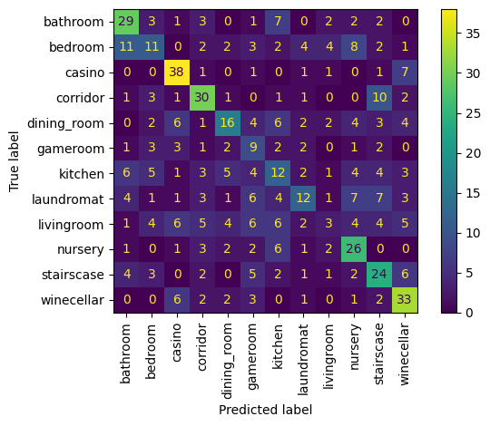

```
|---------------------------------|
|----- SVM: model_svm_dense_key_150_4_8 -----|
|---------------------------------|

Model name: model_svm_dense_key_150_4_8
Parameters Train: {'SVC__C': 0.25, 'SVC__penalty': 'l1'}

Cohen's Kappa Train: 27.72
Balanced Accuracy Train: 33.70%
Accuracy Train: 33.75%

Cohen's Kappa Test: 34.48
Balanced Accuracy Test: 38.48%
Accuracy Test: 40.00%

Classification Report
              precision    recall  f1-score   support

    bathroom       0.52      0.56      0.54        50
     bedroom       0.24      0.22      0.23        50
      casino       0.66      0.82      0.73        50
    corridor       0.55      0.54      0.55        50
 dining_room       0.36      0.20      0.26        50
    gameroom       0.26      0.35      0.30        26
     kitchen       0.19      0.22      0.21        50
  laundromat       0.36      0.32      0.34        50
  livingroom       0.16      0.12      0.14        50
     nursery       0.49      0.55      0.52        44
  stairscase       0.33      0.36      0.35        50
  winecellar       0.50      0.54      0.52        50

    accuracy                           0.40       570
   macro avg       0.38      0.40      0.39       570
weighted avg       0.39      0.40      0.39       570

Confusion Matrix:
```

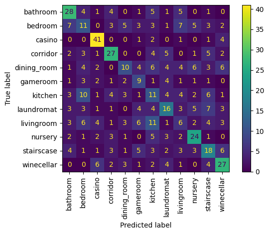

```
|---------------------------------|
|----- SVM: model_svm_dense_key_50_6_12 -----|
|---------------------------------|

Model name: model_svm_dense_key_50_6_12
Parameters Train: {'SVC__C': 0.25, 'SVC__penalty': 'l1'}

Cohen's Kappa Train: 32.91
Balanced Accuracy Train: 38.48%
Accuracy Train: 38.50%

Cohen's Kappa Test: 37.38
Balanced Accuracy Test: 40.22%
Accuracy Test: 42.63%

Classification Report
              precision    recall  f1-score   support

    bathroom       0.53      0.60      0.56        50
     bedroom       0.32      0.24      0.27        50
      casino       0.63      0.76      0.69        50
    corridor       0.57      0.52      0.54        50
 dining_room       0.41      0.28      0.33        50
    gameroom       0.25      0.35      0.29        26
     kitchen       0.35      0.28      0.31        50
  laundromat       0.41      0.38      0.40        50
  livingroom       0.14      0.08      0.10        50
     nursery       0.42      0.64      0.50        44
  stairscase       0.31      0.30      0.31        50
  winecellar       0.49      0.68      0.57        50

    accuracy                           0.43       570
   macro avg       0.40      0.43      0.41       570
weighted avg       0.41      0.43      0.41       570

Confusion Matrix:
```

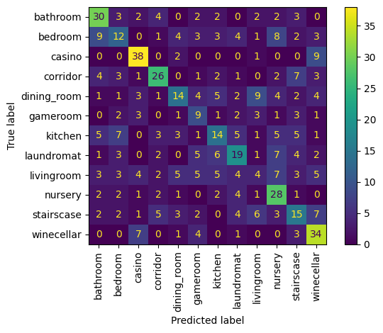

```
|---------------------------------|
|----- SVM: model_svm_dense_key_150_6_12 -----|
|---------------------------------|

Model name: model_svm_dense_key_150_6_12
Parameters Train: {'SVC__C': 0.25, 'SVC__penalty': 'l1'}

Cohen's Kappa Train: 26.28
Balanced Accuracy Train: 32.41%
Accuracy Train: 32.42%

Cohen's Kappa Test: 31.81
Balanced Accuracy Test: 34.55%
Accuracy Test: 37.54%

Classification Report
              precision    recall  f1-score   support

    bathroom       0.50      0.58      0.54        50
     bedroom       0.15      0.12      0.13        50
      casino       0.67      0.76      0.71        50
    corridor       0.50      0.60      0.55        50
 dining_room       0.16      0.10      0.12        50
    gameroom       0.11      0.15      0.13        26
     kitchen       0.26      0.20      0.23        50
  laundromat       0.49      0.46      0.47        50
  livingroom       0.15      0.12      0.13        50
     nursery       0.40      0.45      0.43        44
  stairscase       0.28      0.30      0.29        50
  winecellar       0.47      0.56      0.51        50

    accuracy                           0.38       570
   macro avg       0.35      0.37      0.35       570
weighted avg       0.35      0.38      0.36       570

Confusion Matrix:
```

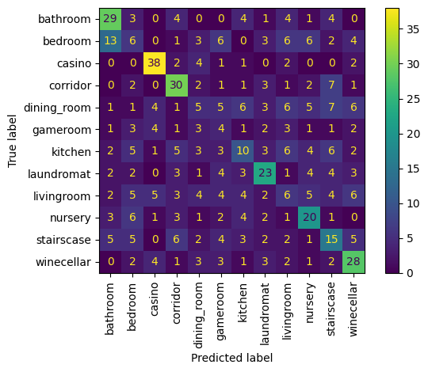

```python
model = [model_svm_dense_key_50_2_4, model_svm_dense_key_150_2_4, model_svm_dense_key_50_4_8, model_svm_dense_key_150_4_8, model_svm_dense_key_50_6_12, model_svm_dense_key_150_6_12]
model_names =  ['model_svm_dense_key_50_2_4', 'model_svm_dense_key_150_2_4', 'model_svm_dense_key_50_4_8', 'model_svm_dense_key_150_4_8', 'model_svm_dense_key_50_6_12', 'model_svm_dense_key_150_6_12']
List_test_data = [des_test_50_2_4, des_test_150_2_4, des_test_50_4_8, des_test_150_4_8, des_test_50_6_12, des_test_150_6_12]

for model_ML, model_name, test_ds in zip(model, model_names, List_test_data):
    y_hat = model_ML.predict(test_ds)
    labels = np.unique(y_test)
    conf_matrix = confusion_matrix(y_hat, y_test, labels=labels)
    mean_balanced_accuracy_score = model_ML.cv_results_['mean_test_balanced_accuracy_score'][model_ML.best_index_]
    mean_accuracy = model_ML.cv_results_['mean_test_accuracy'][model_ML.best_index_]

    accuracy = accuracy_score(y_hat, y_test)
    Balanced_accuracy = balanced_accuracy_score(y_hat, y_test)
    cohen_kappa = cohen_kappa_score(y_hat, y_test)

    print()
    print('|---------------------------------|')
    print(f'|----- SVM: {model_name} -----|')
    print('|---------------------------------|')
    print()
    print(f"Model name: {model_name}")
    print(f"Parameters Train: {model_ML.best_params_}")
    print()
    print(f"Cohen\'s Kappa Train: {round(model_ML.best_score_ * 100, 2)}")
    print(f'Balanced Accuracy Train: {mean_balanced_accuracy_score * 100:.2f}%')
    print(f'Accuracy Train: {mean_accuracy * 100:.2f}%')
    print()
    print(f'Cohen\'s Kappa Test: {cohen_kappa*100:.2f}')
    print(f'Balanced Accuracy Test: {Balanced_accuracy * 100:.2f}%')
    print(f'Accuracy Test: {accuracy * 100:.2f}%')
    print()
    print('Classification Report')
    print(classification_report(y_test, y_hat, target_names=labels))
    print("Confusion Matrix:")
    ConfusionMatrixDisplay.from_predictions(y_test, y_hat, display_labels=labels, xticks_rotation="vertical")
    plt.tight_layout()
    plt.show()
    print()
```

# *SVM model using Dense feature and Keypoints PCA*

#### **Concatenate the DataSet Dense and Keypoints**

```python
des_train_50_2_4 = np.concatenate([pca_train_50_2_4, feat_train], axis = 1)
des_test_50_2_4 = np.concatenate([pca_test_50_2_4, feat_test], axis = 1)

des_train_150_2_4 = np.concatenate([pca_train_150_2_4, feat_train], axis = 1)
des_test_150_2_4 = np.concatenate([test_150_2_4, feat_test], axis = 1)

des_train_50_4_8 = np.concatenate([pca_train_50_4_8, feat_train], axis = 1)
des_test_50_4_8 = np.concatenate([pca_test_50_4_8, feat_test], axis = 1)

des_train_150_4_8 = np.concatenate([pca_train_150_4_8, feat_train], axis = 1)
des_test_150_4_8 = np.concatenate([test_150_4_8, feat_test], axis = 1)

des_train_50_6_12 = np.concatenate([pca_train_50_6_12, feat_train], axis = 1)
des_test_50_6_12 = np.concatenate([test_50_6_12, feat_test], axis = 1)

des_train_150_6_12 = np.concatenate([pca_train_150_6_12, feat_train], axis = 1)
des_test_150_6_12 = np.concatenate([pca_test_150_6_12, feat_test], axis = 1)
```

#### **Model**

```python
parameters = [
  {'SVC__C': 2.**np.arange(-2, 12, 0.8),
   'SVC__penalty': ['l1', 'l2'],
   }
  ]

svm_pipe = Pipeline(steps=[
                 ('scale', StandardScaler()),
                 ('SVC', LinearSVC(random_state=RANDOM_SEED, dual=False))
                 ])

model_svm_dense_key_50_2_4    = GridSearchCV(estimator = svm_pipe, param_grid = parameters, refit='cohen_kappa_score', cv=kfold, scoring=scoring, n_jobs=-1 )
model_svm_dense_key_150_2_4   = GridSearchCV(estimator = svm_pipe, param_grid = parameters, refit='cohen_kappa_score', cv=kfold, scoring=scoring, n_jobs=-1 )
model_svm_dense_key_50_4_8    = GridSearchCV(estimator = svm_pipe, param_grid = parameters, refit='cohen_kappa_score', cv=kfold, scoring=scoring, n_jobs=-1 )
model_svm_dense_key_150_4_8   = GridSearchCV(estimator = svm_pipe, param_grid = parameters, refit='cohen_kappa_score', cv=kfold, scoring=scoring, n_jobs=-1 )
model_svm_dense_key_50_6_12   = GridSearchCV(estimator = svm_pipe, param_grid = parameters, refit='cohen_kappa_score', cv=kfold, scoring=scoring, n_jobs=-1 )
model_svm_dense_key_150_6_12  = GridSearchCV(estimator = svm_pipe, param_grid = parameters, refit='cohen_kappa_score', cv=kfold, scoring=scoring, n_jobs=-1 )
```

#### **Fit model**

```python
model_svm_dense_key_50_2_4.fit(des_train_50_2_4, y_train)
model_svm_dense_key_150_2_4.fit(des_train_150_2_4, y_train)
model_svm_dense_key_50_4_8.fit(des_train_50_4_8, y_train)
model_svm_dense_key_150_4_8.fit(des_train_150_4_8, y_train)
model_svm_dense_key_50_6_12.fit(des_train_50_6_12, y_train)
model_svm_dense_key_150_6_12.fit(des_train_150_6_12, y_train)
```

```
GridSearchCV(cv=StratifiedKFold(n_splits=6, random_state=123, shuffle=True),
             estimator=Pipeline(steps=[('scale', StandardScaler()),
                                       ('SVC',
                                        LinearSVC(dual=False,
                                                  random_state=123))]),
             n_jobs=-1,
             param_grid=[{'SVC__C': array([2.50000000e-01, 4.35275282e-01, 7.57858283e-01, 1.31950791e+00,
       2.29739671e+00, 4.00000000e+00, 6.96440451e+00, 1.21257325e+01,
       2.11121266e+01,...83474e+01, 6.40000000e+01, 1.11430472e+02,
       1.94011721e+02, 3.37794025e+02, 5.88133558e+02, 1.02400000e+03,
       1.78288755e+03, 3.10418753e+03]),
                          'SVC__penalty': ['l1', 'l2']}],
             refit='cohen_kappa_score',
             scoring={'accuracy': make_scorer(accuracy_score),
                      'balanced_accuracy_score': make_scorer(balanced_accuracy_score),
                      'cohen_kappa_score': make_scorer(cohen_kappa_score)})
```

#### **Results models**

```
|---------------------------------|
|----- SVM: pca_model_svm_dense_key_50_2_4 -----|
|---------------------------------|

Model name: pca_model_svm_dense_key_50_2_4
Parameters Train: {'SVC__C': 0.25, 'SVC__penalty': 'l1'}

Cohen's Kappa Train: 27.55
Balanced Accuracy Train: 33.60%
Accuracy Train: 33.58%

Cohen's Kappa Test: 32.18
Balanced Accuracy Test: 35.64%
Accuracy Test: 37.89%

Classification Report
              precision    recall  f1-score   support

    bathroom       0.54      0.56      0.55        50
     bedroom       0.19      0.16      0.17        50
      casino       0.56      0.70      0.62        50
    corridor       0.44      0.56      0.49        50
 dining_room       0.34      0.24      0.28        50
    gameroom       0.18      0.23      0.20        26
     kitchen       0.24      0.18      0.21        50
  laundromat       0.38      0.34      0.36        50
  livingroom       0.22      0.12      0.16        50
     nursery       0.40      0.50      0.44        44
  stairscase       0.24      0.30      0.27        50
  winecellar       0.54      0.60      0.57        50

    accuracy                           0.38       570
   macro avg       0.36      0.37      0.36       570
weighted avg       0.36      0.38      0.37       570

Confusion Matrix:
```

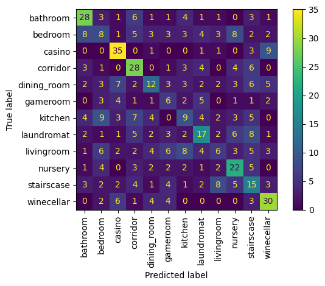

```
|---------------------------------|
|----- SVM: pca_model_svm_dense_key_150_2_4 -----|
|---------------------------------|

Model name: pca_model_svm_dense_key_150_2_4
Parameters Train: {'SVC__C': 0.25, 'SVC__penalty': 'l1'}

Cohen's Kappa Train: 19.0
Balanced Accuracy Train: 25.74%
Accuracy Train: 25.75%

Cohen's Kappa Test: 18.69
Balanced Accuracy Test: 22.74%
Accuracy Test: 25.44%

Classification Report
              precision    recall  f1-score   support

    bathroom       0.39      0.58      0.46        50
     bedroom       0.21      0.14      0.17        50
      casino       0.32      0.24      0.28        50
    corridor       0.41      0.34      0.37        50
 dining_room       0.07      0.04      0.05        50
    gameroom       0.09      0.15      0.11        26
     kitchen       0.20      0.10      0.13        50
  laundromat       0.11      0.04      0.06        50
  livingroom       0.20      0.18      0.19        50
     nursery       0.30      0.48      0.37        44
  stairscase       0.07      0.08      0.07        50
  winecellar       0.35      0.66      0.46        50

    accuracy                           0.25       570
   macro avg       0.23      0.25      0.23       570
weighted avg       0.23      0.25      0.23       570

Confusion Matrix:
```

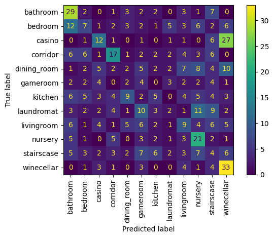

```
|---------------------------------|
|----- SVM: pca_model_svm_dense_key_50_4_8 -----|
|---------------------------------|

Model name: pca_model_svm_dense_key_50_4_8
Parameters Train: {'SVC__C': 0.43527528164806206, 'SVC__penalty': 'l1'}

Cohen's Kappa Train: 26.46
Balanced Accuracy Train: 32.60%
Accuracy Train: 32.58%

Cohen's Kappa Test: 28.78
Balanced Accuracy Test: 31.89%
Accuracy Test: 34.74%

Classification Report
              precision    recall  f1-score   support

    bathroom       0.56      0.60      0.58        50
     bedroom       0.26      0.20      0.22        50
      casino       0.46      0.58      0.51        50
    corridor       0.45      0.50      0.47        50
 dining_room       0.31      0.22      0.26        50
    gameroom       0.23      0.35      0.27        26
     kitchen       0.19      0.14      0.16        50
  laundromat       0.31      0.30      0.31        50
  livingroom       0.06      0.02      0.03        50
     nursery       0.35      0.48      0.40        44
  stairscase       0.22      0.26      0.24        50
  winecellar       0.44      0.54      0.48        50

    accuracy                           0.35       570
   macro avg       0.32      0.35      0.33       570
weighted avg       0.32      0.35      0.33       570

Confusion Matrix:
```

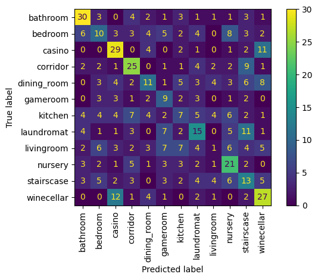

```
|---------------------------------|
|----- SVM: pca_model_svm_dense_key_150_4_8 -----|
|---------------------------------|

Model name: pca_model_svm_dense_key_150_4_8
Parameters Train: {'SVC__C': 0.25, 'SVC__penalty': 'l1'}

Cohen's Kappa Train: 20.1
Balanced Accuracy Train: 26.72%
Accuracy Train: 26.75%

Cohen's Kappa Test: 19.63
Balanced Accuracy Test: 25.73%
Accuracy Test: 26.32%

Classification Report
              precision    recall  f1-score   support

    bathroom       0.27      0.40      0.33        50
     bedroom       0.08      0.06      0.07        50
      casino       0.45      0.28      0.35        50
    corridor       0.38      0.44      0.41        50
 dining_room       0.20      0.22      0.21        50
    gameroom       0.15      0.27      0.19        26
     kitchen       0.23      0.10      0.14        50
  laundromat       0.29      0.20      0.24        50
  livingroom       0.18      0.12      0.14        50
     nursery       0.27      0.36      0.31        44
  stairscase       0.20      0.22      0.21        50
  winecellar       0.39      0.50      0.44        50

    accuracy                           0.26       570
   macro avg       0.26      0.26      0.25       570
weighted avg       0.26      0.26      0.25       570

Confusion Matrix:
```

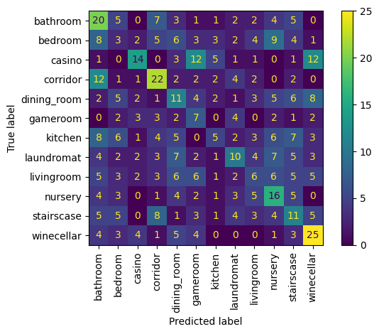

```
|---------------------------------|
|----- SVM: pca_model_svm_dense_key_50_6_12 -----|
|---------------------------------|

Model name: pca_model_svm_dense_key_50_6_12
Parameters Train: {'SVC__C': 0.43527528164806206, 'SVC__penalty': 'l1'}

Cohen's Kappa Train: 24.64
Balanced Accuracy Train: 30.93%
Accuracy Train: 30.92%

Cohen's Kappa Test: 24.36
Balanced Accuracy Test: 28.35%
Accuracy Test: 30.70%

Classification Report
              precision    recall  f1-score   support

    bathroom       0.41      0.72      0.53        50
     bedroom       0.21      0.08      0.12        50
      casino       0.55      0.56      0.55        50
    corridor       0.52      0.48      0.50        50
 dining_room       0.17      0.10      0.13        50
    gameroom       0.18      0.27      0.22        26
     kitchen       0.16      0.10      0.12        50
  laundromat       0.15      0.16      0.15        50
  livingroom       0.19      0.12      0.15        50
     nursery       0.25      0.32      0.28        44
  stairscase       0.19      0.24      0.21        50
  winecellar       0.42      0.52      0.46        50

    accuracy                           0.31       570
   macro avg       0.28      0.31      0.28       570
weighted avg       0.29      0.31      0.29       570

Confusion Matrix:
```

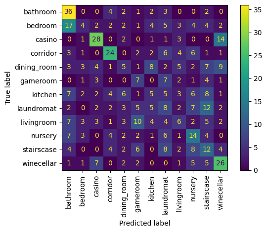

```
|---------------------------------|
|----- SVM: pca_model_svm_dense_key_150_6_12 -----|
|---------------------------------|

Model name: pca_model_svm_dense_key_150_6_12
Parameters Train: {'SVC__C': 0.25, 'SVC__penalty': 'l1'}

Cohen's Kappa Train: 20.0
Balanced Accuracy Train: 26.65%
Accuracy Train: 26.67%

Cohen's Kappa Test: 23.78
Balanced Accuracy Test: 29.45%
Accuracy Test: 30.18%

Classification Report
              precision    recall  f1-score   support

    bathroom       0.46      0.48      0.47        50
     bedroom       0.21      0.24      0.23        50
      casino       0.46      0.46      0.46        50
    corridor       0.37      0.44      0.40        50
 dining_room       0.26      0.24      0.25        50
    gameroom       0.20      0.31      0.24        26
     kitchen       0.28      0.20      0.23        50
  laundromat       0.15      0.12      0.13        50
  livingroom       0.19      0.16      0.17        50
     nursery       0.33      0.36      0.34        44
  stairscase       0.25      0.24      0.24        50
  winecellar       0.38      0.38      0.38        50

    accuracy                           0.30       570
   macro avg       0.29      0.30      0.30       570
weighted avg       0.30      0.30      0.30       570

Confusion Matrix:
```

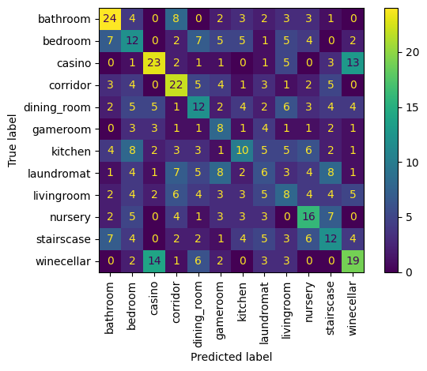

```python
model = [model_svm_dense_key_50_2_4, model_svm_dense_key_150_2_4, model_svm_dense_key_50_4_8, model_svm_dense_key_150_4_8, model_svm_dense_key_50_6_12, model_svm_dense_key_150_6_12]
model_names =  ['pca_model_svm_dense_key_50_2_4', 'pca_model_svm_dense_key_150_2_4', 'pca_model_svm_dense_key_50_4_8',
                'pca_model_svm_dense_key_150_4_8', 'pca_model_svm_dense_key_50_6_12', 'pca_model_svm_dense_key_150_6_12']
List_test_data = [des_test_50_2_4, des_test_150_2_4, des_test_50_4_8, des_test_150_4_8, des_test_50_6_12, des_test_150_6_12]

for model_ML, model_name, test_ds in zip(model, model_names, List_test_data):
    y_hat = model_ML.predict(test_ds)
    labels = np.unique(y_test)
    conf_matrix = confusion_matrix(y_hat, y_test, labels=labels)
    mean_balanced_accuracy_score = model_ML.cv_results_['mean_test_balanced_accuracy_score'][model_ML.best_index_]
    mean_accuracy = model_ML.cv_results_['mean_test_accuracy'][model_ML.best_index_]

    accuracy = accuracy_score(y_hat, y_test)
    Balanced_accuracy = balanced_accuracy_score(y_hat, y_test)
    cohen_kappa = cohen_kappa_score(y_hat, y_test)

    print()
    print('|---------------------------------|')
    print(f'|----- SVM: {model_name} -----|')
    print('|---------------------------------|')
    print()
    print(f"Model name: {model_name}")
    print(f"Parameters Train: {model_ML.best_params_}")
    print()
    print(f"Cohen\'s Kappa Train: {round(model_ML.best_score_ * 100, 2)}")
    print(f'Balanced Accuracy Train: {mean_balanced_accuracy_score * 100:.2f}%')
    print(f'Accuracy Train: {mean_accuracy * 100:.2f}%')
    print()
    print(f'Cohen\'s Kappa Test: {cohen_kappa*100:.2f}')
    print(f'Balanced Accuracy Test: {Balanced_accuracy * 100:.2f}%')
    print(f'Accuracy Test: {accuracy * 100:.2f}%')
    print()
    print('Classification Report')
    print(classification_report(y_test, y_hat, target_names=labels))
    print("Confusion Matrix:")
    ConfusionMatrixDisplay.from_predictions(y_test, y_hat, display_labels=labels, xticks_rotation="vertical")
    plt.tight_layout()
    plt.show()
    print()
```